# Group Project Analysis report 2

Daksh Shah

1/25/2022

### Introduction.

The data set includes records and observations from the year 2012 to 2018 for traffic violations that occurred in Maryland. The total number of records in the data set is 1.04 million, with 431,200 remaining after sample distribution. There are 35 columns in which the observations are organized.

*“A traffic violation is defined as an act that violates the traffic laws of the state or country in question.”(Admin, 2020)*

##### General Examples of Traffic Violation

- Over speed
- Not using the seat belt
- Avoiding stop signs and red light
- Driving under drugs/alcohol influence and so on.

##### Understanding some important columns in the Data set.

- Agency : Agency issuing the traffic violation. (Example: MCP is Montgomery County Police)
- Alcohol : If the traffic violation included an alcohol related
- Belts : If traffic violation involved a seat belt violation.
- Contributed To Accident : If the traffic violation was a contributing factor in an accident.
- Date Of Stop : Date of the traffic violation.
- Fatal : If traffic violation involved a fatality.
- Gender : Gender of the driver (F = Female, M = Male)
- HAZMAT : If the traffic violation involved hazardous materials.
- Latitude : Latitude location of the traffic violation.
- Longitude : Longitude location of the traffic violation.
- Personal Injury : If traffic violation involved Personal Injury.
- Property Damage : If traffic violation involved Property Damage.
- Race : Race of the driver. (Example: Asian, Black, White, Other, etc.)
- SubAgency : Court code representing the district of assignment of the officer. R15 = 1st district, Rockville B15 = 2nd district, Bethesda SS15 = 3rd district, Silver Spring WG15 = 4th district, Wheaton G15 = 5th district, Germantown M15 = 6th district, Gaithersburg / Montgomery Village HQ15 = Headquarters and Special Operations *Time Of Stop : Time of the traffic violation.
- VehicleType : Type of vehicle (Examples: Automobile, Station Wagon, Heavy Duty Truck, etc.)
- Violation Type : Violation type. (Examples: Warning, Citation, SERO)
- Work Zone : If the traffic violation was in a work zone.

```r
summary(df_Daksh)
```

```
##      Date.Of.Stop      Time.Of.Stop    Agency
##  03/17/2015:   440   22:53:00:   647   MCP:431200
##  04/10/2018:   418   22:47:00:   636
##  05/06/2014:   415   23:10:00:   634
##  12/08/2015:   404   23:30:00:   634
##  04/18/2018:   394   22:42:00:   632
##  01/25/2017:   386   22:48:00:   628
##  (Other)   :428743   (Other) :427389
##                                            SubAgency
##  4th district, Wheaton                          :107575
##  3rd district, Silver Spring                    : 87287
##  2nd district, Bethesda                         : 66156
##  6th district, Gaithersburg / Montgomery Village: 56690
##  1st district, Rockville                        : 50582
##  5th district, Germantown                       : 49060
##  (Other)                                        : 13850
##                                                                                     Description
##  DRIVER FAILURE TO OBEY PROPERLY PLACED TRAFFIC CONTROL DEVICE INSTRUCTIONS               : 34497
##  FAILURE TO DISPLAY REGISTRATION CARD UPON DEMAND BY POLICE OFFICER                       : 20370
##  DRIVING VEHICLE ON HIGHWAY WITH SUSPENDED REGISTRATION                                   : 14686
##  FAILURE OF INDIVIDUAL DRIVING ON HIGHWAY TO DISPLAY LICENSE TO UNIFORMED POLICE ON DEMAND: 11311
##  DRIVER USING HANDS TO USE HANDHELD TELEPHONE WHILEMOTOR VEHICLE IS IN MOTION             : 10339
##  DISPLAYING EXPIRED REGISTRATION PLATE ISSUED BY ANY STATE                                : 10034
##  (Other)                                                                                  :329963
##                           Location         Latitude        Longitude
##  IS 370 @ IS 270              :   672   Min.   :-94.61   Min.   :-151.26
##  WAYNE AVE @ DALE DR          :   629   1st Qu.: 39.03   1st Qu.: -77.19
##  W/B IS 370 @ IS 270          :   612   Median : 39.07   Median : -77.09
##  WOODFIELD RD @ EMORY GROVE RD:   529   Mean   : 39.08   Mean   : -77.10
##  RANDOLPH / COLIE             :   500   3rd Qu.: 39.14   3rd Qu.: -77.04
##  10901 WESTLAKE DRIVE         :   493   Max.   : 77.19   Max.   :  41.51
##  (Other)                      :427765   NA's   :31581    NA's   :31581
##  Accident    Belts        Personal.Injury Property.Damage Fatal
##  No:431200   No :416331   No :426162      No :423005      No :431105
##              Yes: 14869   Yes:  5038      Yes:  8195      Yes:    95
##
##
##
##
##
```

[output cut: 41 more lines]

```
##  MD     :374786   A - Marked Patrol            :354642
##  VA     : 14335   Q - Marked Laser             : 41041
##  DC     : 14111   B - Unmarked Patrol          : 13901
##  XX     :  5800   S - License Plate Recognition:  4644
##  PA     :  2746   O - Foot Patrol              :  4274
##  FL     :  2416   L - Motorcycle               :  3742
##  (Other): 17006   (Other)                      :  8956
##                                 Geolocation
##                                       : 31581
##  (39.045425, -76.9907366666667)       :   189
##  (39.0462766666667, -76.990695)       :   140
##  (39.109775, -76.91044)               :   113
##  (39.0056183333333, -77.0123283333333):    89
##  (39.11061, -76.9897983333333)        :    87
##  (Other)                              :399001
```

- From the above summary we understand some basic idea about the data set.
  - Traffic Violation distribution based on Gender, Male drivers have been commited more violation then that of Female and Unknown gender.
  - 4 types of violation are observed Citation, ESERO, SERO and Warning.
  - Most of the Violation have not contributed to accident.

### Visualizaing the Data

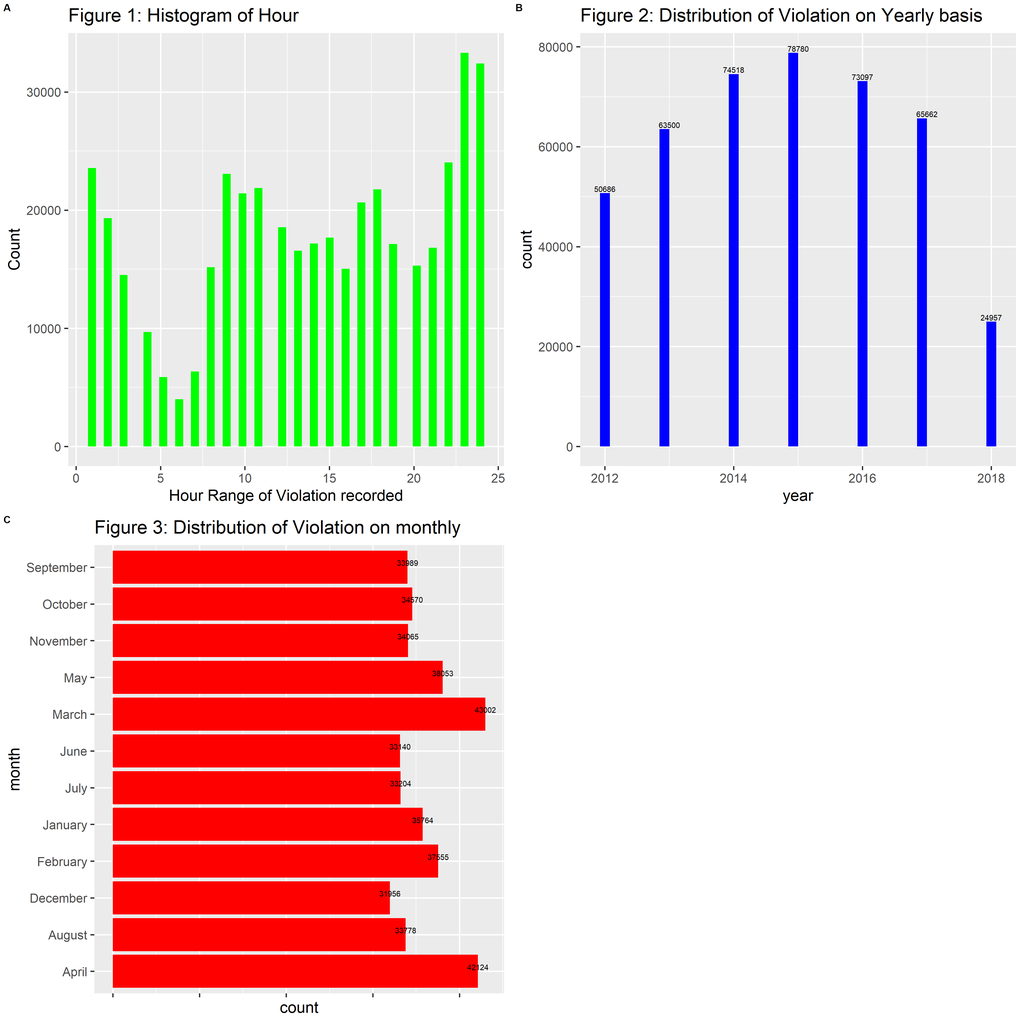

```r
g1 <- ggplot(df_Daksh, aes(hour)) +
 geom_histogram(bins = 50, fill = "Green") +
 ggtitle("Figure 1: Histogram of Hour") +
 ylab("Count") +
 xlab("Hour Range of Violation recorded") +
 theme(plot.title = element_text(hjust = 0.5))+ theme_gray(base_size = 22)

g2<- ggplot(df_Daksh, aes(x = year)) +
geom_histogram(fill = "blue", bins = 40)+
scale_fill_hue(c = 70)+
ggtitle("Figure 2: Distribution of Violation on Yearly basis")+
theme(plot.title = element_text(hjust = 0.5),legend.position="right")+
geom_text(stat='count',aes(label=..count..),vjust=-0.25)+ theme_gray(base_size = 22)

g3 <- ggplot(df_Daksh, aes(y = month)) +
geom_bar(fill = "red")+
scale_fill_hue(c = 70)+
ggtitle("Figure 3: Distribution of Violation on monthly")+
theme(plot.title = element_text(hjust = 0.5),legend.position="right")+
geom_text(stat='count',aes(label=..count..),vjust=-0.25) + theme_gray(base_size = 22)


ggarrange(g1, g2, g3 + rremove("x.text"),
          labels = c("A", "B", "C"),
          ncol = 2, nrow = 2)
```

#### Study of violation over the years (2012 - 2018)

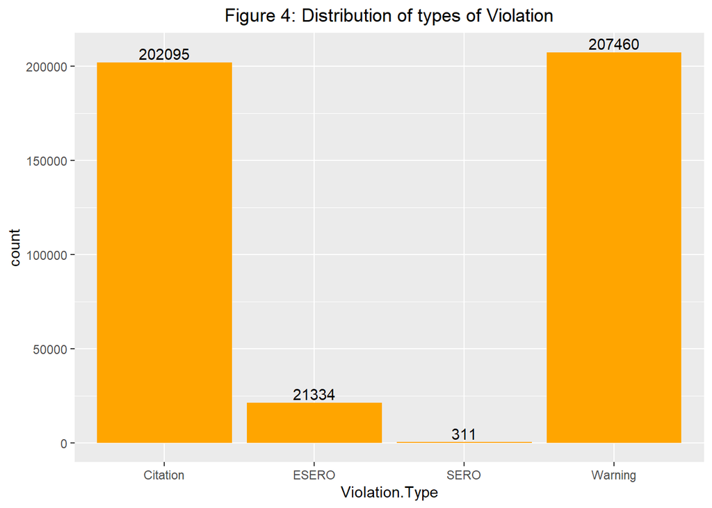

```r
g4 <- ggplot(df_Daksh, aes(x = Violation.Type)) +
geom_bar(fill = "orange")+
ggtitle("Figure 4: Distribution of types of Violation")+
theme(plot.title = element_text(hjust = 0.5),legend.position="right")+
geom_text(stat='count',aes(label=..count..),vjust=-0.25)
g4
```

- From the above chart - Barplot we understand the distribution of Violation type.

### Tabulation of various categorical columns with hour column

```r
bh <- table(df_Daksh$hour, df_Daksh$Belts)
bh
```

```
##
##         No   Yes
##   1  23163   401
##   2  18982   328
##   3  14258   257
##   4   9500   185
##   5   5730   129
##   6   3831   159
##   7   6043   300
##   8  14383   788
##   9  21863  1196
##   10 20338  1079
##   11 20697  1171
##   12 17484  1061
##   13 15794   778
##   14 16344   828
##   15 16786   878
##   16 14321   709
##   17 19968   682
##   18 21114   641
##   19 16583   546
##   20 14805   506
##   21 16347   470
##   22 23513   530
##   23 32636   678
##   24 31848   569
```

- **View of people reported for violation of Belts on hourly basis.**

```r
ah <- table(df_Daksh$hour, df_Daksh$Alcohol)
ah
```

```
##
##         No   Yes
##   1  23542    22
##   2  19292    18
##   3  14498    17
##   4   9651    34
##   5   5846    13
##   6   3985     5
##   7   6324    19
##   8  15126    45
##   9  23001    58
##   10 21374    43
##   11 21843    25
##   12 18531    14
##   13 16552    20
##   14 17142    30
##   15 17633    31
##   16 14994    36
##   17 20591    59
##   18 21667    88
##   19 17051    78
##   20 15267    44
##   21 16794    23
##   22 24038     5
##   23 33296    18
##   24 32405    12
```

- **View of people reported for violation of Alcohol on hourly basis.**

```r
hh <- table(df_Daksh$hour, df_Daksh$HAZMAT)
hh
```

```
##
##         No   Yes
##   1  23562     2
##   2  19310     0
##   3  14515     0
##   4   9685     0
##   5   5859     0
##   6   3990     0
##   7   6343     0
##   8  15168     3
##   9  23053     6
##   10 21414     3
##   11 21861     7
##   12 18543     2
##   13 16570     2
##   14 17171     1
##   15 17662     2
##   16 15030     0
##   17 20643     7
##   18 21755     0
##   19 17129     0
##   20 15307     4
##   21 16817     0
##   22 24043     0
##   23 33314     0
##   24 32417     0
```

- **View of people reported for violation of Harzardious Materials on hourly basis.**

```r
hf <- table(df_Daksh$hour, df_Daksh$Fatal)
hf
```

```
##
##         No   Yes
##   1  23561     3
##   2  19306     4
##   3  14513     2
##   4   9684     1
##   5   5854     5
##   6   3987     3
##   7   6341     2
##   8  15169     2
##   9  23056     3
##   10 21411     6
##   11 21859     9
##   12 18541     4
##   13 16567     5
##   14 17170     2
##   15 17660     4
##   16 15028     2
##   17 20636    14
##   18 21751     4
##   19 17127     2
##   20 15309     2
##   21 16815     2
##   22 24035     8
##   23 33311     3
##   24 32414     3
```

- **View of Fatalities reported after violation on hourly basis.**

### Data encoding for Heatmap

```r
df_Daksh <- df_Daksh %>%
  mutate(belten = if_else(Belts == "No", 0, 1)) %>%
  mutate(alcoholn = if_else(Alcohol == "No", 0, 1))%>%
  mutate(hazmatn = if_else(HAZMAT == "No", 0,1))%>%
  mutate(personinjuryn = if_else(Personal.Injury == "No", 0, 1))%>%
  mutate(propdamn = if_else(Property.Damage == "No", 0, 1))%>%
  mutate(fataln = if_else(Fatal == "No", 0, 1))%>%
  mutate(workzonen = if_else(Work.Zone == "No", 0, 1))%>%
  mutate(genn = if_else(Gender == "F", 0, 1)) %>%
  mutate(violation_y = if_else(Belts == "Yes" | Commercial.License == "Yes"
                               | Alcohol == "Yes" | HAZMAT == "Yes", "Yes", "No"))

df_Daksh <- df_Daksh %>%
  mutate(Day_view = case_when(hour <=5 ~ "Midnight",
                              (hour >5 & hour <=11) ~ "Morning",
                              (hour>11 & hour <=16)  ~ "Afternoon",
                              (hour > 16 & hour <= 20) ~ "Evening",
                               hour >20 ~ "Night"))
df_Daksh <- df_Daksh %>%
  mutate(Dayn = case_when(Day_view == "Midnight" ~ 0,
                          Day_view == "Morning" ~ 1,
                          Day_view == "Afternoon" ~ 2,
                          Day_view == "Evening" ~ 3,
                          Day_view == "Night" ~ 4))
```

### Heat Map to understand the correlation.

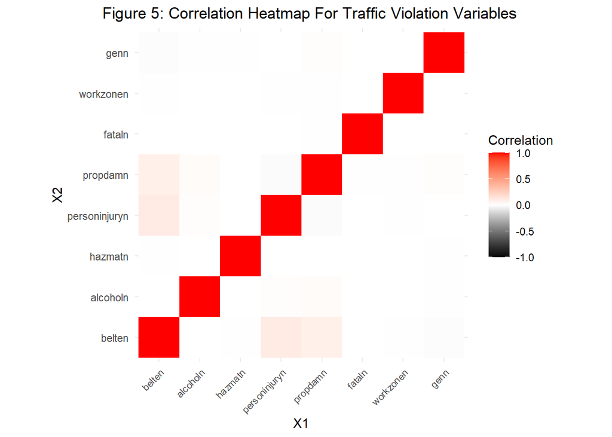

```r
heat_violation <- c("belten","alcoholn","hazmatn","personinjuryn","propdamn","fataln","workzonen","genn")
heat_plot <- df_Daksh[,heat_violation]

#plot correlation heatmap for understainding the relation between various columns
qplot(x=X1, y=X2, data=melt(cor(heat_plot, use="p")), fill=value, geom="tile") +
   scale_fill_gradient2(low = "black", high = "red", mid = "white",
   midpoint = 0, limit = c(-1,1), space = "Lab",
   name="Correlation") +
   theme_minimal()+
   theme(axis.text.x = element_text(angle = 45, vjust = 1, size = 8, hjust = 1))+
   coord_fixed()+
   ggtitle("Figure 5: Correlation Heatmap For Traffic Violation Variables") +
   theme(plot.title = element_text(hjust = 0.4))
```

- According to the heat map above, there is a very weak association between those who violate the law by not wearing seat belts and personal injury, with no other correlation between other variables plotted in the heat map.

### Chi-square test of independce

- We will check if the relation of various categorical columns with othe categorical columns
- H0 = The variable Gender and Violation Type are Independent.
- H1 = The variable Gender and Violation Type are Dependent.

```r
chi1 <- xtabs(~ Gender + Violation.Type, data = df_Daksh)
chi1
```

```
##       Violation.Type
## Gender Citation  ESERO   SERO Warning
##      F    59512   6605     80   75979
##      M   142516  14727    231  131060
##      U       67      2      0     421
```

```r
chisq.test(chi1)
```

```
##
##  Pearson's Chi-squared test
##
## data:  chi1
## X-squared = 2756.1, df = 6, p-value < 2.2e-16
```

- From the above observation we understand that the Gender and Violation type have some dependence.
- H0 = The variable Race and Violation Type are Independent.
- H1 = The variable Race and Violation Type are Dependent.

```r
chi2 <- xtabs(~ Race + Violation.Type, data = df_Daksh)
chi2
```

```
##                  Violation.Type
## Race              Citation ESERO  SERO Warning
##   ASIAN               9883  1368    12   13915
##   BLACK              65607  6669    85   63657
##   HISPANIC           48383  5876    97   36760
##   NATIVE AMERICAN      390    57     0     492
##   OTHER               9436  1006    13   12516
##   WHITE              68396  6358   104   80120
```

```r
chisq.test(chi2)
```

```
##
##  Pearson's Chi-squared test
##
## data:  chi2
## X-squared = 4298.7, df = 15, p-value < 2.2e-16
```

- From the above observation we understand that the Race and Violation type have some dependence.

### ANOVA Analysis for variance.

- The ANOVA analysis cannot be performed since we do not have any continuous quantitative variable in our observation.

### Data Preparation

```r
df_Daksh <- df_Daksh %>%
  mutate(Quaterly_view2 = case_when(month_code <=3 ~ 1,
                              (month_code >3 & month_code <=6) ~ 2,
                              (month_code>6 & month_code <=9)  ~ 3,
                              (month_code > 9 & month_code <= 12) ~ 4))

df_Daksh$cartype <-  as.numeric(factor(df_Daksh$VehicleType,levels = c("01 - Motorcycle", "02 - Automobile","03 - Station Wagon","04 - Limousine",
"05 - Light Duty Truck", "06 - Heavy Duty Truck","07 - Truck/Road Tractor", "08 - Recreational Vehicle",  "09 - Farm Vehicle", "10 - Transit Bus",
"11 - Cross Country Bus","12 - School Bus","13 - Ambulance","13 - Ambulance(Emerg)","14 - Ambulance",
"14 - Ambulance(Non-Emerg)","15 - Fire Vehicle","15 - Fire(Emerg)","16 - Fire(Non-Emerg)","17 - Police(Emerg)",
"18 - Police Vehicle","18 - Police(Non-Emerg)","19 - Moped","20 - Commercial Rig","21 - Tandem Trailer",
"22 - Mobile Home","23 - Travel/Home Trailer","24 - Camper","25 - Utility Trailer","26 - Boat Trailer",
"27 - Farm Equipment","28 - Other","29 - Unknown"),
labels =c("1","2","3","3","4","4","4","5","5","6","6","6","7","7","7","7","7","7","7","7","7","7","1","5","8","8","8","8","8","8","5","5","5"),ordered = TRUE))
```

- Reducing the Vehicle type to generalized for car type
- Encoding month code to quater basis

### Modeling.

#### Liner model

```r
l1 <- lm(train$hour ~ Gender + Race, data = train)

summary(l1)
```

```
##
## Call:
## lm(formula = train$hour ~ Gender + Race, data = train)
##
## Residuals:
##      Min       1Q   Median       3Q      Max
## -13.6125  -5.0221   0.3694   6.3694  12.6200
##
## Coefficients:
##                     Estimate Std. Error t value Pr(>|t|)
## (Intercept)         14.21417    0.05687 249.944  < 2e-16 ***
## GenderM             -0.15027    0.02795  -5.377 7.58e-08 ***
## GenderU             -2.64218    0.40210  -6.571 5.01e-11 ***
## RaceBLACK           -0.10051    0.05898  -1.704  0.08834 .
## RaceHISPANIC        -0.43328    0.06133  -7.065 1.61e-12 ***
## RaceNATIVE AMERICAN  0.39837    0.28335   1.406  0.15974
## RaceOTHER            0.18666    0.07862   2.374  0.01758 *
## RaceWHITE           -0.19203    0.05841  -3.288  0.00101 **
## ---
## Signif. codes:  0 '***' 0.001 '**' 0.01 '*' 0.05 '.' 0.1 ' ' 1
##
## Residual standard error: 7.166 on 301834 degrees of freedom
## Multiple R-squared:  0.0007237,  Adjusted R-squared:  0.0007005
## F-statistic: 31.23 on 7 and 301834 DF,  p-value: < 2.2e-16
```

#### Logistics model

```r
m1 <- glm(Belts ~ Gender + Race + train$Work.Zone + train$cartype + train$Commercial.Vehicle + train$Quaterly_view2 , data = train, family = binomial)

summary(m1)
```

```
##
## Call:
## glm(formula = Belts ~ Gender + Race + train$Work.Zone + train$cartype +
##     train$Commercial.Vehicle + train$Quaterly_view2, family = binomial,
##     data = train)
##
## Deviance Residuals:
##     Min       1Q   Median       3Q      Max
## -0.6078  -0.2721  -0.2560  -0.2492   3.0658
##
## Coefficients:
##                              Estimate Std. Error z value Pr(>|z|)
## (Intercept)                 -3.626415   0.054538 -66.494  < 2e-16 ***
## GenderM                     -0.150781   0.021032  -7.169 7.54e-13 ***
## GenderU                     -1.439802   0.504255  -2.855  0.00430 **
## RaceBLACK                   -0.097093   0.045713  -2.124  0.03367 *
## RaceHISPANIC                 0.043571   0.047017   0.927  0.35408
## RaceNATIVE AMERICAN         -0.357352   0.256635  -1.392  0.16378
## RaceOTHER                    0.254424   0.057125   4.454 8.43e-06 ***
## RaceWHITE                    0.033542   0.044776   0.749  0.45379
## train$Work.ZoneYes           1.173321   0.431634   2.718  0.00656 **
## train$cartype                0.198469   0.011154  17.793  < 2e-16 ***
## train$Commercial.VehicleYes -1.203319   0.215997  -5.571 2.53e-08 ***
## train$Quaterly_view2        -0.027393   0.008964  -3.056  0.00224 **
## ---
## Signif. codes:  0 '***' 0.001 '**' 0.01 '*' 0.05 '.' 0.1 ' ' 1
##
## (Dispersion parameter for binomial family taken to be 1)
##
##     Null deviance: 90414  on 301841  degrees of freedom
## Residual deviance: 89962  on 301830  degrees of freedom
## AIC: 89986
##
## Number of Fisher Scoring iterations: 6
```

```r
m2 <- glm(Alcohol ~ Gender + Race + train$Work.Zone + train$cartype + train$Commercial.Vehicle + train$Quaterly_view2 , data = train, family = binomial)
summary(m2)
```

```
##
## Call:
## glm(formula = Alcohol ~ Gender + Race + train$Work.Zone + train$cartype +
##     train$Commercial.Vehicle + train$Quaterly_view2, family = binomial,
##     data = train)
##
## Deviance Residuals:
##     Min       1Q   Median       3Q      Max
## -0.1048  -0.0678  -0.0594  -0.0528   4.1990
##
## Coefficients:
##                              Estimate Std. Error z value Pr(>|z|)
## (Intercept)                  -9.11165    0.59904 -15.210  < 2e-16 ***
## GenderM                       0.22983    0.09668   2.377 0.017439 *
## GenderU                     -11.47292  360.72767  -0.032 0.974628
## RaceBLACK                     2.05979    0.58410   3.526 0.000421 ***
## RaceHISPANIC                  2.29512    0.58522   3.922 8.79e-05 ***
## RaceNATIVE AMERICAN          -9.91893  252.76333  -0.039 0.968697
## RaceOTHER                     1.62485    0.63633   2.553 0.010666 *
## RaceWHITE                     2.68569    0.58057   4.626 3.73e-06 ***
## train$Work.ZoneYes          -12.21763  835.92175  -0.015 0.988339
## train$cartype                 0.11634    0.05047   2.305 0.021149 *
## train$Commercial.VehicleYes  -1.32211    1.00569  -1.315 0.188634
## train$Quaterly_view2          0.01579    0.03875   0.407 0.683700
## ---
## Signif. codes:  0 '***' 0.001 '**' 0.01 '*' 0.05 '.' 0.1 ' ' 1
##
## (Dispersion parameter for binomial family taken to be 1)
##
##     Null deviance: 7847.9  on 301841  degrees of freedom
## Residual deviance: 7738.2  on 301830  degrees of freedom
## AIC: 7762.2
##
## Number of Fisher Scoring iterations: 17
```

```r
m3 <- glm(HAZMAT ~ Gender + Race + train$Work.Zone + train$cartype + train$Commercial.Vehicle + train$Quaterly_view2 , data = train, family = binomial)
summary(m3)
```

```
##
## Call:
## glm(formula = HAZMAT ~ Gender + Race + train$Work.Zone + train$cartype +
##     train$Commercial.Vehicle + train$Quaterly_view2, family = binomial,
##     data = train)
##
## Deviance Residuals:
##     Min       1Q   Median       3Q      Max
## -0.2552  -0.0131  -0.0088  -0.0066   4.6194
##
## Coefficients:
##                              Estimate Std. Error z value Pr(>|z|)
## (Intercept)                  -13.2087     1.2837 -10.290  < 2e-16 ***
## GenderM                        0.1312     0.4843   0.271  0.78644
## GenderU                      -10.8164  3346.4385  -0.003  0.99742
## RaceBLACK                      0.3781     1.0612   0.356  0.72165
## RaceHISPANIC                   0.3903     1.0748   0.363  0.71650
## RaceNATIVE AMERICAN          -13.7415  2952.4126  -0.005  0.99629
## RaceOTHER                    -13.6598   594.2872  -0.023  0.98166
## RaceWHITE                      0.1256     1.0617   0.118  0.90584
## train$Work.ZoneYes           -13.7855  9930.9372  -0.001  0.99889
## train$cartype                  0.6827     0.1283   5.321 1.03e-07 ***
## train$Commercial.VehicleYes    1.7346     0.7727   2.245  0.02479 *
## train$Quaterly_view2           0.5869     0.2062   2.846  0.00442 **
## ---
## Signif. codes:  0 '***' 0.001 '**' 0.01 '*' 0.05 '.' 0.1 ' ' 1
##
## (Dispersion parameter for binomial family taken to be 1)
##
##     Null deviance: 501.1  on 301841  degrees of freedom
## Residual deviance: 463.5  on 301830  degrees of freedom
## AIC: 487.5
##
## Number of Fisher Scoring iterations: 22
```

### References

- Traffic Violations in Maryland County. (2018, May 9). Kaggle. https://www.kaggle.com/rounak041993/traffic-violations-in-maryland-county
- ANOVA Test: Definition & Uses (Updated 2022). (2022, January 18). Qualtrics. Retrieved January 25, 2022, from https://www.qualtrics.com/experience-management/research/anova/#:%7E:text=You%20would%20use%20ANOVA%20to,are%20unequal%20(or%20different).
- Chi-square test of independence in R. (n.d.). Stats and R. Retrieved January 25, 2022, from https://statsandr.com/blog/chi-square-test-of-independence-in-r/
- R CODER. (2021, December 5). The ggplot2 package | R CHARTS. R CHARTS | A Collection of Charts and Graphs Made with the R Programming Language. https://r-charts.com/ggplot2/
- Admin, T. S. (2020, October 15). Traffic Violations: Definition, Types, Consequences and Examples. School Bus Tracking System with TrackSchoolBus Apps. https://www.trackschoolbus.com/traffic-violations/